# TP de Monte-Carlo

```r
set.seed(0802)
```

# 1 Exercice 1 : RANDU

On étudie le générateur suivant :

$$x_i = 65539 x_{i-1} \mod 2^{31}$$
et on pose $u_i = \frac{x_i}{2^{31}}$ comme générateur de loi uniforme.

### 1.0.1 Question 1

Montrons que $x_i = 6 x_{i-1} - 9 x_{i-2}$

$$\begin{align*}
x_i &= 65539 x_{i-1} \mod 2^{31} \\&= (2^{16} +3) x_{i-1} \mod 2^{31} \\
&= (2^{16} +3)^2 x_{i-2} \mod 2^{31}\\& = (2^{32} +9 + 6\times 2^{16}) x_{i-2} \mod 2^{31} \\
&= 6\times(2^{16} + 3) x_{i-2} - 9 x_{i-2} \mod 2^{31} \quad \text{ car $2^{32}x_{i-2}$ divisible par $2^{31}$} \\
&= 6 x_{i-1} - 9 x_{i-2} \\ \text{Donc :}& \\
u_i &= 6 u_{i-1} - 9 u_{i-2}
\end{align*}$$

### 1.0.2 Question 2

```r
randu <- function(n, start = 1, return_u = TRUE){
  init0 = as.double(start)
  init1 = init0 * 65539 %% (2^31)

  if(return_u){
    init0 = init0 / 65539
    init1 = init1 / 65539
  }

  res = vector(length = n)
  res[1] = init0
  res[2] = init1
  modulo <- ifelse(return_u, 1, 2^31)
  for(i in seq_len(n-3)){
    res[i+2] = (6 * res[i+1] - 9 * res[i]) %% modulo
  }
  res
}
simul <- randu(20000)
head(simul, 15)
```

```
##  [1] 1.525809e-05 1.000000e+00 9.998627e-01 9.991761e-01 9.962923e-01
##  [6] 9.851691e-01 9.443843e-01 7.997833e-01 2.992417e-01 5.974000e-01
## [11] 8.912251e-01 9.707502e-01 8.034758e-01 8.410260e-02 2.733334e-01
```

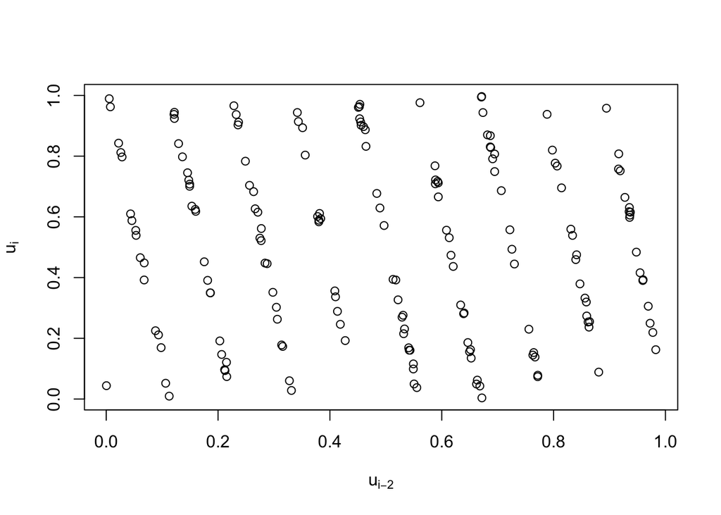

```r
val = zoo::rollapply(simul, width = 3, function(x){
  if(0.5 <= x[2] & x[2] <= 0.51){
    return(c(x[1], x[3]))
  }
})

plot(val, xlab = expression(u[i-2]), ylab = expression(u[i]))
```

Toutes les valeurs sont sur certains hyperplans

### 1.0.3 Question 3

```r
library(rgl)
toutes_donnees = zoo::rollapply(simul, width = 3, function(x){
  return(c(x[1],x[2], x[3]))
})

plot3d(toutes_donnees, col = "red",
       xlab = expression(u[i-2]),
       ylab = expression(u[i-1]),
       zlab = expression(u[i]))
```

[interactive chart not shown]

### 1.0.4 Question 4

```r
simul_x <- randu(20000, return_u = FALSE)
sapply(simul_x[1:30], function(x) paste(intToBits(x), collapse = ""))
```

```
##  [1] "0100000000000000000000000000000000000000000000000000000000000000"
##  [2] "0101000000000000000000000000000001000000000000000000000000000000"
##  [3] "0100000100000000000000000000000000010100000000000000000000000000"
##  [4] "0101000101000000000000000000000001010001010000000000000000000000"
##  [5] "0100000001000100000000000000000000000101000101000000000000000000"
##  [6] "0101000001010101000000000000000001000100010000010100000000000000"
##  [7] "0100000101000101000100000000000000010000010100010100010000000000"
##  [8] "0101000100000001000000010000000001010101000101010101000001000000"
##  [9] "0100000000010001010000010100000000000001010001000000010000000100"
## [10] "0101000000010101000001010000010001000001000100010001010000010100"
## [11] "0100000100010001000101000001010100010101010001010000000000000000"
## [12] "0101000101010101010100000101000101000100000001000100000100010100"
## [13] "0100000001010101010100010100000000000101000001010101010100010100"
## [14] "0101000001000101010100000100010001000100010001000101000100010100"
## [15] "0100000101010100010100010101010100010000010001010100010001000000"
## [16] "0101000100010100000100000101010101000000010101010000010101010000"
## [17] "0100000000000100010101000100010100000000000001000100000100010000"
## [18] "0101000000000101010001000000000101010000000000000101000001000100"
## [19] "0100000100000100010000000100000101000101000001010001010101010100"
## [20] "0101000101000101010100000101000101000000010100010100010100000000"
## [21] "0100000001000001010100010100000000000000010101010000010101000100"
## [22] "0101000001010001000100000100010001000000000101000001000001010000"
## [23] "0100000101000000000000010101010100010100010001010100000100010100"
## [24] "0101000100000100000000010001010101000101010000010100010001010000"
## [25] "0100000000010101000000010101000100000100000100000100000100000000"
## [26] "0101000000010001000100010001000001010101000001000000010001000100"
## [27] "0100000100010101010101010101010000000000010000010101010000010000"
## [28] "0101000101010001010101010101010000010001010000010001010001010100"
## [29] "0100000001010000010101010101010000010001000000010101000000010100"
## [30] "0101000001000001010001010101010000000000010001010100000100010000"
```

# 2 Exercice 2 : Rejet et loi de Laplace

### 2.0.1 Question 1

On va chercher à générer une loi de Laplace :
$$p(x) = \frac{1}{2}\exp(- \lvert x \rvert)$$
Pour simuler la loi de Laplace on va procéder de la façon suivante :

1. Simuler une loi exponentielle $X \sim\mathcal E (1)$
2. Simuler une loi uniforme $U \sim \mathcal U(0,1)$
3. Si $U < 0,5$ on renvoie $X$, sinon $-X$

Pour simuler la loi exponentielle on pourrait également utiliser la méthode de la fonction de répartition inverse. Pour rappel, cette méthode dit que si l’on a une loi $\mathbb P_X$ de fonction de répartition $F_X$ inversible alors, si $U\sim \mathcal U([0,1])$ alors $F_X^{-1}(U)\sim \mathbb P_X$ est une variable aléatoire de fonction de répartition $F_X$.

Dans notre cas, si $X\sim\mathcal E(\lambda)$ alors $\DeclareMathOperator{\e}{e}F_X(t) = 1-\e^{-\lambda t}$. Donc :
$$u = 1-\e^{-\lambda t} \iff t = - \frac{\ln(1-u)}{\lambda} \implies F_X^{-1}(U) = -\frac{\ln(1-U)}{\lambda}$$

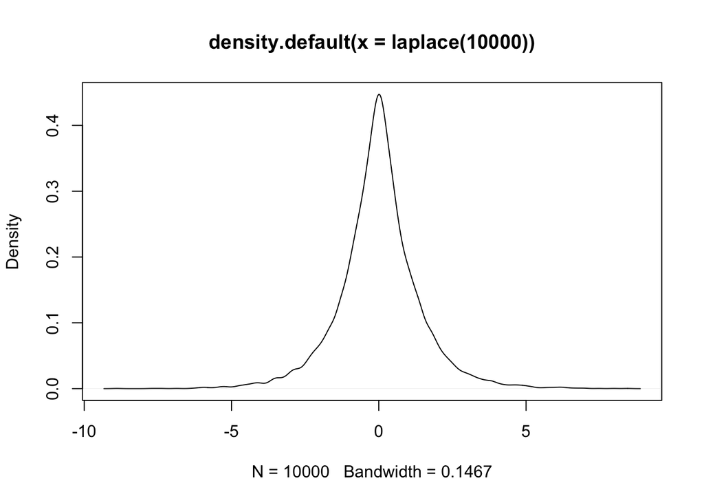

```r
laplace <- function(n){
  u = runif(n)
  x = rexp(n)
  data <- data.frame(u,x)
  apply(data,1, function(v){
    if(v[1] < 0.5)
      return(v[2])
    else
      return(-v[2])
  })

}
plot(density(laplace(10000)))
```

On veut maintenant générer une loi $\mathcal N(0,1)$ avec l’algorithme d’acceptation-rejet et la loi de Laplace. Pour cela on cherche $C$ telle que :
$$\frac{f(x)}{p(x)} \leq C \text{ avec }f(x) =
\frac{1}{\sqrt{2\pi}} \e^{-\frac{x^2}{2}}$$
Calculons :
$$\begin{align*}
\frac{f(x)}{p(x)} &= \sqrt{\frac{2}{\pi}} \e ^{-\frac{x^2}{2} + \lvert x \rvert} \\
&= \sqrt{\frac{2}{\pi}} \e ^{-\frac{x^2 + 2 \lvert x \rvert}{2}} \\
&= \sqrt{\frac{2}{\pi}} \e ^{-\frac{(\lvert x \rvert -1)^2}{2}} \e^{\frac{1}{2}} \leq \sqrt{\frac{2}{\pi}} \e^{\frac{1}{2}} = C
\end{align*}$$

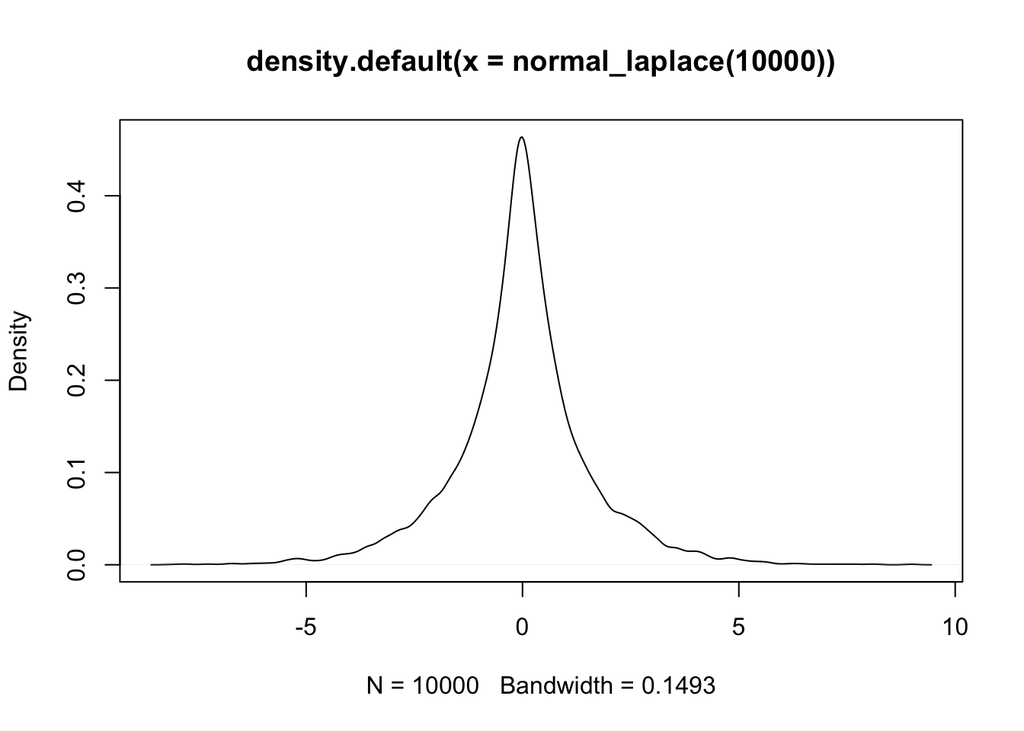

```r
normal_laplace <- function(n){
  sapply(1:n, function(n){
    nonAccepte <- TRUE
    while({
      #On accepte si b1 <= b2
      # donc on continue tant que b2 < b1
      u <- runif(1)
      x1 <- laplace(1)

      b1 <- sqrt(1/2*pi) * exp(1/2 - abs(x1))
      b2 <- 1/sqrt(2*pi) * exp(-x1^2/2)
      (u*b1 <= b2)
    }){}
    x1
  })
}
plot(density(normal_laplace(10000)))
```

### 2.0.3 Question 3

Le taux d’acceptation est donné par :

$$\begin{align*}
C\times U\times p(x) \leq f(x) &\iff
U \sqrt{\frac{2}{\pi}} \e^{\frac{1}{2}} \frac{1}{2}\e^{- \lvert x \rvert} \leq \frac{1}{\sqrt{2\pi}} \e^{-\frac{x^2}{2}}
\\ &\iff U \e^{\frac{1}{2}} \e^{- \lvert x \rvert} \leq \e^{-\frac{x^2}{2}} \\
&\iff
\log(U) + \frac{1}{2} - \lvert x \rvert \leq - \frac{x^2}{2} \\
&\iff
1 - 2 \lvert x \rvert + x^2 \leq - 2\log(U) \\
&\iff
(\lvert x \rvert -1)^2 \leq - 2\log(U)
\end{align*}$$

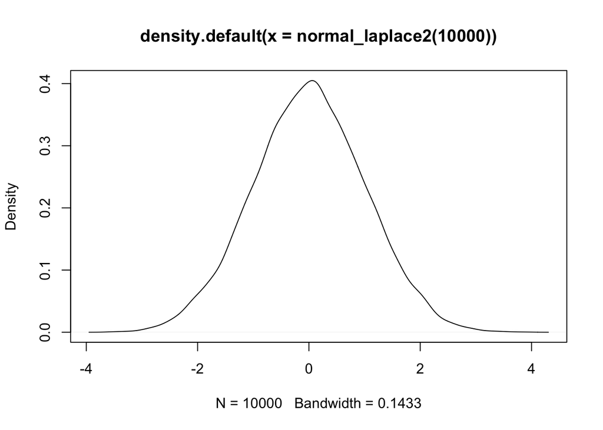

```r
normal_laplace2 <- function(n){
  sapply(1:n, function(n){
    nonAccepte <- TRUE
    while({
      #On accepte si b1 <= b2
      # donc on continue tant que b2 < b1
      u <- runif(1)
      x1 <- laplace(1)

      (abs(x1) -1)^2 > -2*log(u)
    }){}
    x1
  })
}
plot(density(normal_laplace2(10000)))
```

### Question 4

Non on ne peut pas faire l’inverse (i.e. générer la loi de Laplace par rejet, en utilisant une loi Normale). En effet :
$$\begin{align*}
\frac{p(x)}{f(x)} &= \sqrt{\frac{\pi}{2}} \e ^{-\lvert x \rvert + \frac{x^2}{2}} \\
&= \sqrt{\frac{\pi}{2}} \e ^{\frac{(\lvert x \rvert -1)^2}{2}} \e^{-\frac{1}{2}}
\underset{x\to \pm\infty}{\longrightarrow} + \infty
\end{align*}$$

On ne peut donc pas majorer le rapport et générer la loi de Laplace par rejet en utilisant une loi Normale

# 3 Exercice 3 : Box-Muller amélioré

### 3.0.1 Question 1

On utilise la méthode de Box-Muller améliorée pour simuler une loi normale $\mathcal N(0,1)$ :

- Générer $U_1,U_2 \sim U([-1,1])$ jusqu’) ce que $U_1^2+U_2^2\leq1$.
- Renvoyer $X = U_1 \sqrt{-2\log(S)/S}$ et $Y = U_2 \sqrt{-2\log(S)/S}$ où $S = U_1^2+U_2^2$.

### 3.0.2 Question 2

La méthode de Box-Muller standard simule $U_1,U_2 \sim U([0,1])$ et renvoie $X = \sqrt{-2\log(U_1)}\cos(2\pi U_2)$, $U = \sqrt{-2\log(U_1)}\sin(2\pi U_2)$

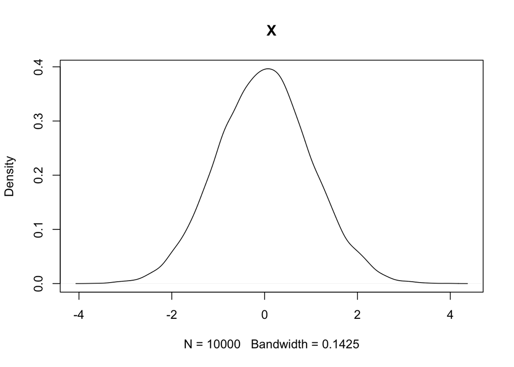

```r
box_muller_ameliore <- function(n){
  result <- sapply(1:n, function(i){

    while({
      u <- runif(2,min = -1, max = 1)
      S = u[1]^2 + u[2]^2
      S > 1
    }){}
    x = u[1] * sqrt(-2 * log(S)/S)
    y = u[2] * sqrt(-2 * log(S)/S)
    c(x, y)
  })
  result <- data.frame(t(result))
  colnames(result) <- c("X", "Y")
  result
}

box_muller <- function(n){
  result <- sapply(1:n, function(i){
    u <- runif(2)
    x = cos(2*pi*u[1]) * sqrt(-2 * log(u[1]))
    y = sin(2*pi*u[2]) * sqrt(-2 * log(u[1]))
    c(x, y)
  })
  result <- data.frame(t(result))
  colnames(result) <- c("X", "Y")
  result
}
simul_box_muller_amelio <- box_muller_ameliore(10000)
plot(density(simul_box_muller_amelio$X),
     main = "X")
```

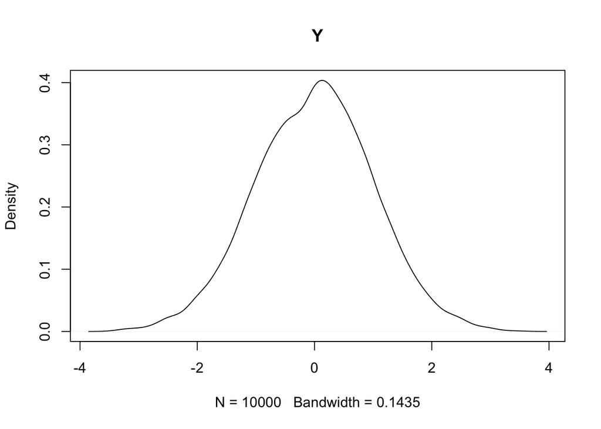

```r
plot(density(simul_box_muller_amelio$Y),
     main = "Y")
```

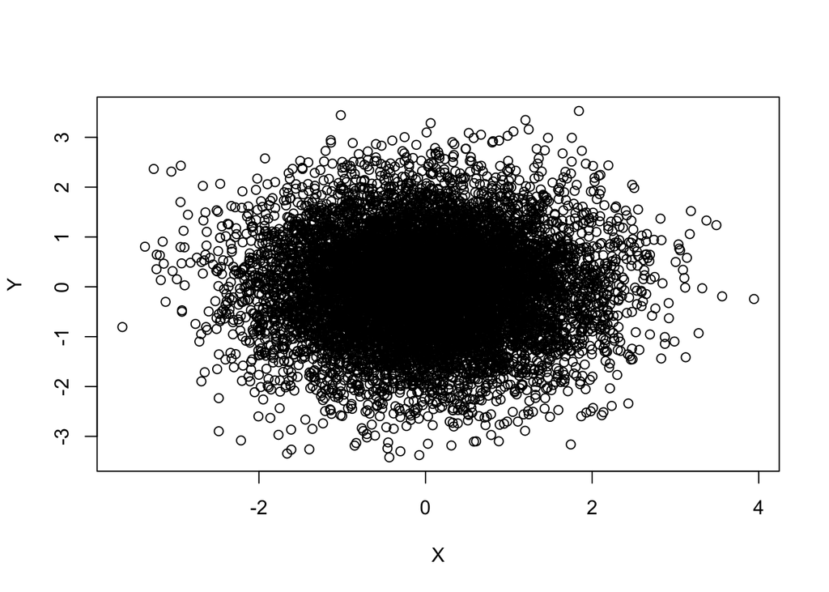

```r
plot(simul_box_muller_amelio)
```

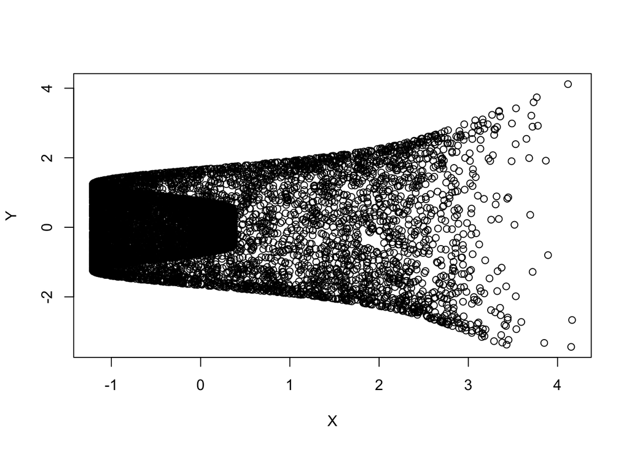

```r
simul_box_muller <- box_muller(10000)
plot(simul_box_muller)
```

```r
microbenchmark::microbenchmark(`Version améliorée` = {
  box_muller_ameliore(10000)
},
`Version classique` = {
  box_muller(10000)
},times = 100)
```

```
## Unit: milliseconds
##               expr      min       lq     mean   median       uq      max neval
##  Version améliorée 28.74166 32.10634 37.43640 38.26939 40.78650 62.67202   100
##  Version classique 24.87912 27.19795 32.69346 33.44553 36.43194 99.74758   100
```

```r
# Ou
# profvis::profvis({
#   box_muller_ameliore(1000)
#   simul_box_muller <- box_muller(1000000)
# })
```

# 4 Exercice 4 : Loi géométrique

La loi géométrique est une loi de probabilité discrète qui peut être définie comme la loi du nombre $X$ d’épreuves de Bernoulli indépendante de probabilité de succès $p \in ]0,1[$nécessaire pour obtenir le premier succès. $X$ est la variable aléatoire donnant le rang du premier succès.

Pour $X \sim \mathcal G(p)$ on a $\mathbb P (X = k) = (1-p)^{k-1} p$.

Pour générer une loi géométrique de paramètre $p$ il suffit donc de générer des lois de bernoulli $\mathcal B(p)$ et de compter le nombre de réalisations nécessaire avant d’obtenir un premier succès. Pour cela il suffit de générer une loi uniforme $U \sim \mathcal U([0,1])$ : on considère qu’il y a succès si $U \leq p$ (on a $\mathbb P(U \leq p) = p$).

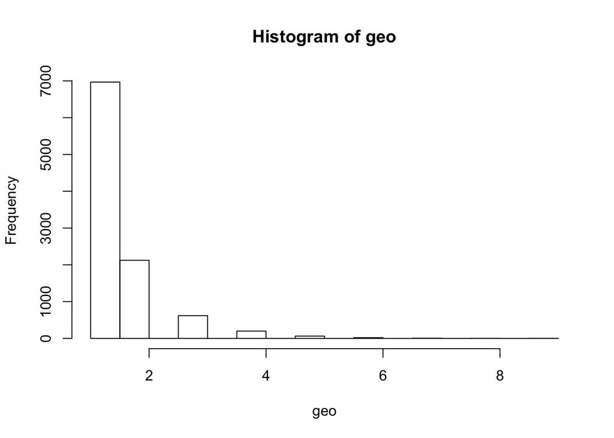

```r
geometrique <- function(n, p){
  sapply(1:n, function(i){
    k=0
    while({
      u = runif(1)
      k = k+1

      u>p}){}
    k
  })
}
p = 0.7
geo <- geometrique(10000, p)
hist(geo)
```

On a :
$$\mathbb E[X] = \frac{1}{p} \quad\text{et}\quad\mathbb V[X] = \frac{1-p}{p^2}$$

```r
t.test(geo, mu = 1/p)
```

```
##
##  One Sample t-test
##
## data:  geo
## t = 0.99307, df = 9999, p-value = 0.3207
## alternative hypothesis: true mean is not equal to 1.428571
## 95 percent confidence interval:
##  1.42085 1.45215
## sample estimates:
## mean of x
##    1.4365
```

```r
t.test((geo - mean(geo))^2, mu = (1-p)/p^2)
```

```
##
##  One Sample t-test
##
## data:  (geo - mean(geo))^2
## t = 1.2237, df = 9999, p-value = 0.2211
## alternative hypothesis: true mean is not equal to 0.6122449
## 95 percent confidence interval:
##  0.5971248 0.6776107
## sample estimates:
## mean of x
## 0.6373678
```

# 5 Exercice 5 : Control variates, variables antithétiques, QMC

# 6 Exercice 6 : Importance sampling

# 7 Exercice 7 : MCMC

# 8 Exercice 8 : Erreur de discrétisation dans le pricing d’option

# 9 Exercice 9 : Cross-Entropy Method